# Assignment_9_Butterfield

Rylie Butterfield

# Assignment 9

## Set Up

```r
library(tidyverse)
library(easystats)
library(kableExtra)
library(GGally)
library(modelr)
```

## Explore the Data

```r
grad <- read_csv("GradSchool_Admissions.csv")

grad%>% kable() %>% kable_classic() %>% scroll_box(height = '250px')
```

| admit | gre | gpa | rank |
| --- | --- | --- | --- |
| 0 | 380 | 3.61 | 3 |
| 1 | 660 | 3.67 | 3 |
| 1 | 800 | 4.00 | 1 |
| 1 | 640 | 3.19 | 4 |
| 0 | 520 | 2.93 | 4 |
| 1 | 760 | 3.00 | 2 |
| 1 | 560 | 2.98 | 1 |
| 0 | 400 | 3.08 | 2 |
| 1 | 540 | 3.39 | 3 |
| 0 | 700 | 3.92 | 2 |
| 0 | 800 | 4.00 | 4 |
| 0 | 440 | 3.22 | 1 |
| 1 | 760 | 4.00 | 1 |
| 0 | 700 | 3.08 | 2 |
| 1 | 700 | 4.00 | 1 |
| 0 | 480 | 3.44 | 3 |
| 0 | 780 | 3.87 | 4 |
| 0 | 360 | 2.56 | 3 |
| 0 | 800 | 3.75 | 2 |
| 1 | 540 | 3.81 | 1 |
| 0 | 500 | 3.17 | 3 |
| 1 | 660 | 3.63 | 2 |
| 0 | 600 | 2.82 | 4 |
| 0 | 680 | 3.19 | 4 |
| 1 | 760 | 3.35 | 2 |
| 1 | 800 | 3.66 | 1 |
| 1 | 620 | 3.61 | 1 |
| 1 | 520 | 3.74 | 4 |
| 1 | 780 | 3.22 | 2 |
| 0 | 520 | 3.29 | 1 |

[output cut: 370 more lines]

```r
summary(grad)
```

```
##      admit             gre             gpa             rank
##  Min.   :0.0000   Min.   :220.0   Min.   :2.260   Min.   :1.000
##  1st Qu.:0.0000   1st Qu.:520.0   1st Qu.:3.130   1st Qu.:2.000
##  Median :0.0000   Median :580.0   Median :3.395   Median :2.000
##  Mean   :0.3175   Mean   :587.7   Mean   :3.390   Mean   :2.485
##  3rd Qu.:1.0000   3rd Qu.:660.0   3rd Qu.:3.670   3rd Qu.:3.000
##  Max.   :1.0000   Max.   :800.0   Max.   :4.000   Max.   :4.000
```

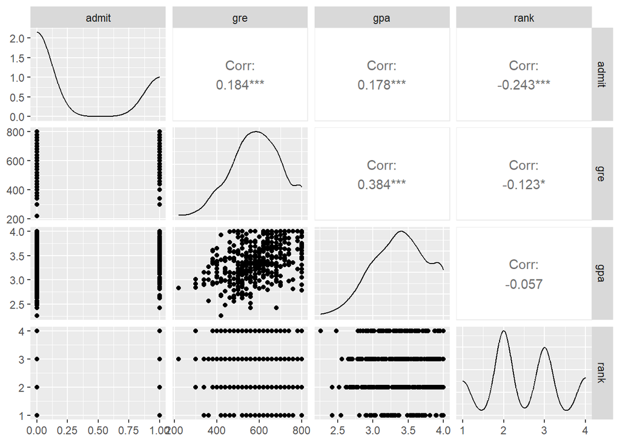

```r
grad %>%
  ggpairs()
```

This set of plots allows us to visualize what is happening with the data. It can be helpful in getting an idea of where to start when analyzing and modeling the data.  
From the plots we can see that there is a possible connection between gpa and gre, so that might be somewhere to start when seeing what influences admission.

Next, we can analyze some potential models:

```r
mod1= glm(admit ~ gpa, data = grad, family = 'binomial')
summary(mod1)
```

```
##
## Call:
## glm(formula = admit ~ gpa, family = "binomial", data = grad)
##
## Coefficients:
##             Estimate Std. Error z value Pr(>|z|)
## (Intercept)  -4.3576     1.0353  -4.209 2.57e-05 ***
## gpa           1.0511     0.2989   3.517 0.000437 ***
## ---
## Signif. codes:  0 '***' 0.001 '**' 0.01 '*' 0.05 '.' 0.1 ' ' 1
##
## (Dispersion parameter for binomial family taken to be 1)
##
##     Null deviance: 499.98  on 399  degrees of freedom
## Residual deviance: 486.97  on 398  degrees of freedom
## AIC: 490.97
##
## Number of Fisher Scoring iterations: 4
```

```r
mod2 = glm(admit ~ gre, data= grad, family = 'binomial')
summary(mod2)
```

```
##
## Call:
## glm(formula = admit ~ gre, family = "binomial", data = grad)
##
## Coefficients:
##              Estimate Std. Error z value Pr(>|z|)
## (Intercept) -2.901344   0.606038  -4.787 1.69e-06 ***
## gre          0.003582   0.000986   3.633  0.00028 ***
## ---
## Signif. codes:  0 '***' 0.001 '**' 0.01 '*' 0.05 '.' 0.1 ' ' 1
##
## (Dispersion parameter for binomial family taken to be 1)
##
##     Null deviance: 499.98  on 399  degrees of freedom
## Residual deviance: 486.06  on 398  degrees of freedom
## AIC: 490.06
##
## Number of Fisher Scoring iterations: 4
```

```r
mod3 = glm(admit ~ rank, data = grad, family = 'binomial')
summary(mod3)
```

```
##
## Call:
## glm(formula = admit ~ rank, family = "binomial", data = grad)
##
## Coefficients:
##             Estimate Std. Error z value Pr(>|z|)
## (Intercept)   0.6366     0.3061   2.080   0.0375 *
## rank         -0.5863     0.1240  -4.728 2.26e-06 ***
## ---
## Signif. codes:  0 '***' 0.001 '**' 0.01 '*' 0.05 '.' 0.1 ' ' 1
##
## (Dispersion parameter for binomial family taken to be 1)
##
##     Null deviance: 499.98  on 399  degrees of freedom
## Residual deviance: 475.71  on 398  degrees of freedom
## AIC: 479.71
##
## Number of Fisher Scoring iterations: 4
```

```r
mod4 = glm(admit ~ gpa + rank + gre, data = grad, family = 'binomial')
summary(mod4)
```

```
##
## Call:
## glm(formula = admit ~ gpa + rank + gre, family = "binomial",
##     data = grad)
##
## Coefficients:
##              Estimate Std. Error z value Pr(>|z|)
## (Intercept) -3.449548   1.132846  -3.045  0.00233 **
## gpa          0.777014   0.327484   2.373  0.01766 *
## rank        -0.560031   0.127137  -4.405 1.06e-05 ***
## gre          0.002294   0.001092   2.101  0.03564 *
## ---
## Signif. codes:  0 '***' 0.001 '**' 0.01 '*' 0.05 '.' 0.1 ' ' 1
##
## (Dispersion parameter for binomial family taken to be 1)
##
##     Null deviance: 499.98  on 399  degrees of freedom
## Residual deviance: 459.44  on 396  degrees of freedom
## AIC: 467.44
##
## Number of Fisher Scoring iterations: 4
```

```r
mod5 = glm(admit ~ gpa:gre, data = grad, family = 'binomial')
summary(mod5)
```

```
##
## Call:
## glm(formula = admit ~ gpa:gre, family = "binomial", data = grad)
##
## Coefficients:
##               Estimate Std. Error z value Pr(>|z|)
## (Intercept) -2.6180659  0.4705940  -5.563 2.65e-08 ***
## gpa:gre      0.0009032  0.0002189   4.126 3.69e-05 ***
## ---
## Signif. codes:  0 '***' 0.001 '**' 0.01 '*' 0.05 '.' 0.1 ' ' 1
##
## (Dispersion parameter for binomial family taken to be 1)
##
##     Null deviance: 499.98  on 399  degrees of freedom
## Residual deviance: 481.98  on 398  degrees of freedom
## AIC: 485.98
##
## Number of Fisher Scoring iterations: 4
```

```r
mod6 = glm(admit ~ gpa:rank, data = grad, family = 'binomial')
summary(mod6)
```

```
##
## Call:
## glm(formula = admit ~ gpa:rank, family = "binomial", data = grad)
##
## Coefficients:
##             Estimate Std. Error z value Pr(>|z|)
## (Intercept)  0.28961    0.29455   0.983 0.325495
## gpa:rank    -0.12949    0.03464  -3.738 0.000186 ***
## ---
## Signif. codes:  0 '***' 0.001 '**' 0.01 '*' 0.05 '.' 0.1 ' ' 1
##
## (Dispersion parameter for binomial family taken to be 1)
##
##     Null deviance: 499.98  on 399  degrees of freedom
## Residual deviance: 485.21  on 398  degrees of freedom
## AIC: 489.21
##
## Number of Fisher Scoring iterations: 4
```

```r
mod7 = glm(admit ~ gpa + gre + gpa:gre, data = grad, family = 'binomial')
summary(mod7)
```

```
##
## Call:
## glm(formula = admit ~ gpa + gre + gpa:gre, family = "binomial",
##     data = grad)
##
## Coefficients:
##               Estimate Std. Error z value Pr(>|z|)
## (Intercept) -13.818700   5.874816  -2.352   0.0187 *
## gpa           3.367918   1.722685   1.955   0.0506 .
## gre           0.017464   0.009606   1.818   0.0691 .
## gpa:gre      -0.004327   0.002787  -1.552   0.1205
## ---
## Signif. codes:  0 '***' 0.001 '**' 0.01 '*' 0.05 '.' 0.1 ' ' 1
##
## (Dispersion parameter for binomial family taken to be 1)
##
##     Null deviance: 499.98  on 399  degrees of freedom
## Residual deviance: 477.85  on 396  degrees of freedom
## AIC: 485.85
##
## Number of Fisher Scoring iterations: 4
```

To visualize the different models, we can compare them and plot them:

```r
# compare all the models directly
compare_performance(mod1, mod2, mod3, mod4, mod5, mod6, mod7, rank = TRUE)
```

```
## # Comparison of Model Performance Indices
##
## Name | Model | Tjur's R2 |  RMSE | Sigma | Log_loss | Score_log
## ---------------------------------------------------------------
## mod4 |   glm |     0.099 | 0.442 |     1 |    0.574 |   -50.496
## mod3 |   glm |     0.060 | 0.451 |     1 |    0.595 |   -49.032
## mod6 |   glm |     0.037 | 0.456 |     1 |    0.607 |   -48.290
## mod7 |   glm |     0.052 | 0.453 |     1 |    0.597 |   -48.633
## mod5 |   glm |     0.044 | 0.456 |     1 |    0.602 |   -48.607
## mod1 |   glm |     0.032 | 0.458 |     1 |    0.609 |   -48.163
## mod2 |   glm |     0.034 | 0.458 |     1 |    0.608 |   -48.247
##
## Name | Score_spherical |   PCP | AIC weights | AICc weights | BIC weights | Performance-Score
## ---------------------------------------------------------------------------------------------
## mod4 |           0.004 | 0.609 |       0.998 |        0.998 |       0.889 |            67.52%
## mod3 |           0.010 | 0.593 |       0.002 |        0.002 |       0.104 |            40.12%
## mod6 |           0.008 | 0.583 |    1.87e-05 |     1.94e-05 |    9.01e-04 |            30.88%
## mod7 |           0.004 | 0.589 |    1.00e-04 |     1.00e-04 |    8.95e-05 |            28.41%
## mod5 |           0.004 | 0.585 |    9.39e-05 |     9.73e-05 |       0.005 |            24.38%
## mod1 |           0.004 | 0.581 |    7.77e-06 |     8.05e-06 |    3.75e-04 |            23.20%
## mod2 |           0.003 | 0.581 |    1.23e-05 |     1.27e-05 |    5.91e-04 |            22.06%
```

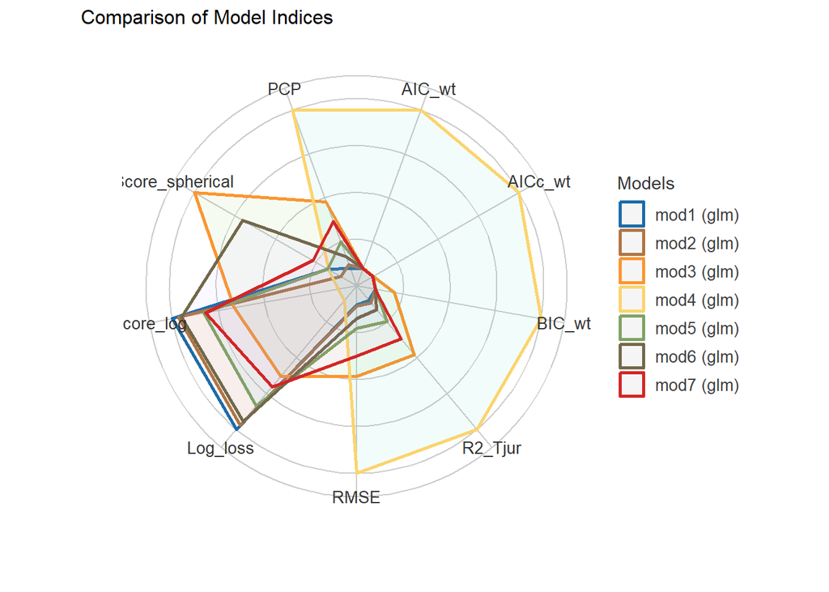

```r
#visually compare the models
compare_performance(mod1, mod2, mod3, mod4, mod5, mod6, mod7) %>% plot()
```

After comparing the models, we can see that mod4 and mod3 are the top two best models.

Now we will plot the models to see if one is better than the other.

[figure not shown]

Overall, it looks like mod4 is the best model, and we will use it to move forward with predictions.

# Prediction

We will make our predictions using mod4.

First we can find the model parameters.

```r
mod4 %>% model_parameters(exponentiate = TRUE)
```

```
## Parameter   | Odds Ratio |       SE |       95% CI |     z |      p
## -------------------------------------------------------------------
## (Intercept) |       0.03 |     0.04 | [0.00, 0.28] | -3.05 | 0.002
## gpa         |       2.17 |     0.71 | [1.15, 4.17] |  2.37 | 0.018
## rank        |       0.57 |     0.07 | [0.44, 0.73] | -4.40 | < .001
## gre         |       1.00 | 1.09e-03 | [1.00, 1.00] |  2.10 | 0.036
```

Then we can create a column in the data frame with the predicted values and plot them to visualize the predictions.

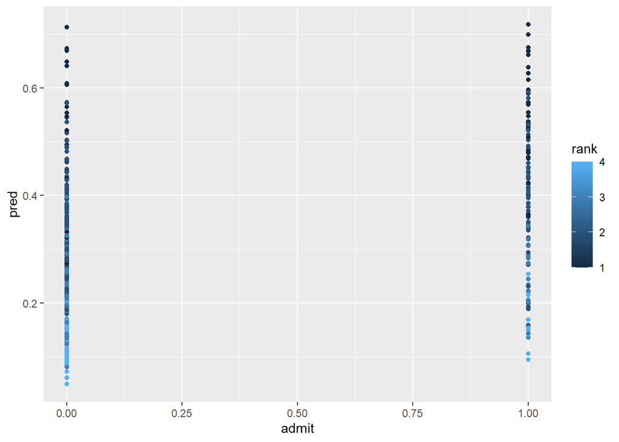

```r
grad2 = grad

#make new column with predictions
grad2$pred = predict(mod4, grad2, type = 'response')

#plot the predictions
grad2 %>%
  ggplot(aes(x = admit, y = pred, color = rank)) +
  geom_point()
```

Both of these should give us information to make conclusions

# Conclusions

1. A higher gpa makes you more likely to be admitted to grad school.
2. A higher gre makes you more likely to be admitted to grad school.
3. A higher rank does not make you more likely to be admitted to grad school.